# Getting started with Jupyter

Jupyter: https://jupyter.org/

### History

**1988: Mathematica**

https://www.wolfram.com/mathematica/

- Created by Stephen Wolfram
- Notebook interface designed by Theodore Gray
- An all-in-one system: language (Wolfram Language), execution environment, scientific libraries

Key architectural details of Mathematica Notebooks:

- Two parts to the system: kernel and front-end
- The front-end sends the input to the kernel, which returns the result, which is displayed
- Mathematica notebooks are objects that can be manipulated by Mathematica programs

**2001: IPython**

https://ipython.org/

Enhanced interactive environment that includes support for data visualization and facilities for distributed and parallel computation

**2005: SageMath** (previously **Sage**)

https://www.sagemath.org/

**SageMath** is a free open-source mathematics software system licensed under the GPL. It builds on top of many existing open-source packages: NumPy, SciPy, matplotlib, Sympy, Maxima, GAP, FLINT, R and many more. Access their combined power through a common, Python-based language or directly via interfaces or wrappers.

Mission: Creating a viable free open source alternative to Magma, Maple, Mathematica and Matlab.

Created by William Stein

**2011: IPython Notebook**

**2014: Project Jupyter**

https://jupyter.org/

Jupyter: Julia, Python, R

- rendered by GitHub
- support by VS Code python plugin
- Google Colab
- Kaggle

## Installation

- With `pip`:

  ```
  pip install jupyterlab
  ```

- Comes included in **Anacoda**, https://www.anaconda.com

  ```
  conda install -c conda-forge jupyterlab
  ```

# Starting

From the command line:

```
jupyter-notebook
```

```
jupyter-lab
```

On remote host:

```
ssh -L localhost:8888:localhost:8888 <server>
```

## Jupyter interface

- Jupyter Notebook
- JupyterLab

Two modes: command mode and edit mode

Command mode keyboard shortcuts:

- a : insert cell above
- b : insert cell below
- dd : delete selected cell
- m : markdown
- Enter: edit mode

Edit mode:

- Tab : code completion or indent
- Shift + Tab : tooltip
- Esc : command mode

## Markdown

Section headings:

- `# Heading 1`
- `## Heading 2`
- `## Heading 3`
- **bold** : `**...**` or `__...__`
- *italic* : `*...*` or `_..._`
- *bold and italic* : `**_..._**`

Lists:

- unordered

  ```
    - item 1
    - item 2
  ```

- ordered

  ```
    1. item 1
    2. item 2
  ```

MathJax https://www.mathjax.org/

$X_i^j$, see $$ a = \sum_i b_i \int_c^d f(x)\,\mathrm{d}x $$

`$...$` for inline math, `$$...$$` for displayed math \begin{align} \dot{x} & = \sigma(y-x) \\ \dot{y} & = \rho x - y - xz \\ \dot{z} & = -\beta z + xy \end{align}

## Examples

```python
2+2
```

```
4
```

```python
import numpy as np
import matplotlib.pyplot as plt
```

```python
x = np.linspace(0, 20, 100)
y = np.sin(x)
s = np.abs(np.random.randn(x.shape[0])) * 100
```

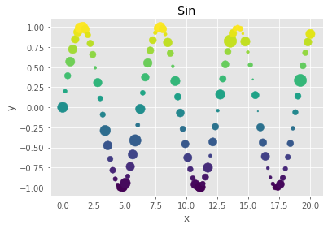

```python
plt.style.use('ggplot')
plt.scatter(x, y, c=y, s=s)
plt.xlabel('x')
plt.ylabel('y')
plt.title('Sin')
plt.grid(True);
```

## Widgets

```python
import ipywidgets as widgets
```

```python
def plot_Lissajous(nx, ny):
    N = 400
    t = np.linspace(0, 2 * np.pi, N)
    x = np.sin(nx * t)
    y = np.cos(ny * t)
    plt.plot(x, y)
    plt.ylim(-1.1, 1.1)
    plt.show()
```

```python
wx = widgets.IntSlider(min=0, max=10, value=2, step=1, description="nx")
wy = widgets.IntSlider(min=0, max=10, value=3, step=1, description="ny", orientation='vertical')
out = widgets.interactive_output(plot_Lissajous, {'nx': wx, 'ny': wy})
ui = widgets.HBox([wy, widgets.VBox([out, wx])])
```

```python
ui
```

## Voilà

Voilà transforms a Jupyter Notebook into a stand-alone web application

```
voila <path-to-notebook>
```

Deployment

https://mybinder.org/

Turn a Git repo into a collection of interactive notebooks